# task1

# Naudingos ir dazniausiai naudojamos funkcijos ir kiti kodai:

# General

builtins() # List all built-in functions

options() # Set options to control how R computes & displays results

?NA # Help page on handling of missing data values

abs(x) # The absolute value of “x”

append() # Add elements to a vector

c(x) # A generic function which combines its arguments

cat(x) # Prints the arguments

cbind() # Combine vectors by row/column (cf. “paste” in Unix)

diff(x) # Returns suitably lagged and iterated differences

gl() # Generate factors with the pattern of their levels

grep() # Pattern matching

identical() # Test if 2 objects are *exactly* equal

jitter() # Add a small amount of noise to a numeric vector

julian() # Return Julian date

length(x) # Return no. of elements in vector x

ls() # List objects in current environment

mat.or.vec() # Create a matrix or vector

paste(x) # Concatenate vectors after converting to character

range(x) # Returns the minimum and maximum of x

rep(1,5) # Repeat the number 1 five times

rev(x) # List the elements of “x” in reverse order

seq(1,10,0.4) # Generate a sequence (1 -> 10, spaced by 0.4)

sequence() # Create a vector of sequences

sign(x) # Returns the signs of the elements of x

sort(x) # Sort the vector x

order(x) # list sorted element numbers of x

tolower(),toupper() # Convert string to lower/upper case letters

unique(x) # Remove duplicate entries from vector

system(“cmd”) # Execute “cmd” in operating system (outside of R)

vector() # Produces a vector of given length and mode

formatC(x) # Format x using ‘C’ style formatting specifications

floor(x), ceiling(x), round(x), signif(x), trunc(x) # rounding functions

Sys.getenv(x) # Get the value of the environment variable “x”

Sys.putenv(x) # Set the value of the environment variable “x”

Sys.time() # Return system time

Sys.Date() # Return system date

getwd() # Return working directory

setwd() # Set working directory

?files # Help on low-level interface to file system

list.files() # List files in a give directory

file.info() # Get information about files

# Graphical

help(package=graphics) # List all graphics functions

plot() # Generic function for plotting of R objects

par() # Set or query graphical parameters

curve(5*x^3,add=T) # Plot an equation as a curve

points(x,y) # Add another set of points to an existing graph

arrows() # Draw arrows [see errorbar script]

abline() # Adds a straight line to an existing graph

lines() # Join specified points with line segments

segments() # Draw line segments between pairs of points

hist(x) # Plot a histogram of x

pairs() # Plot matrix of scatter plots

matplot() # Plot columns of matrices

# Examples:

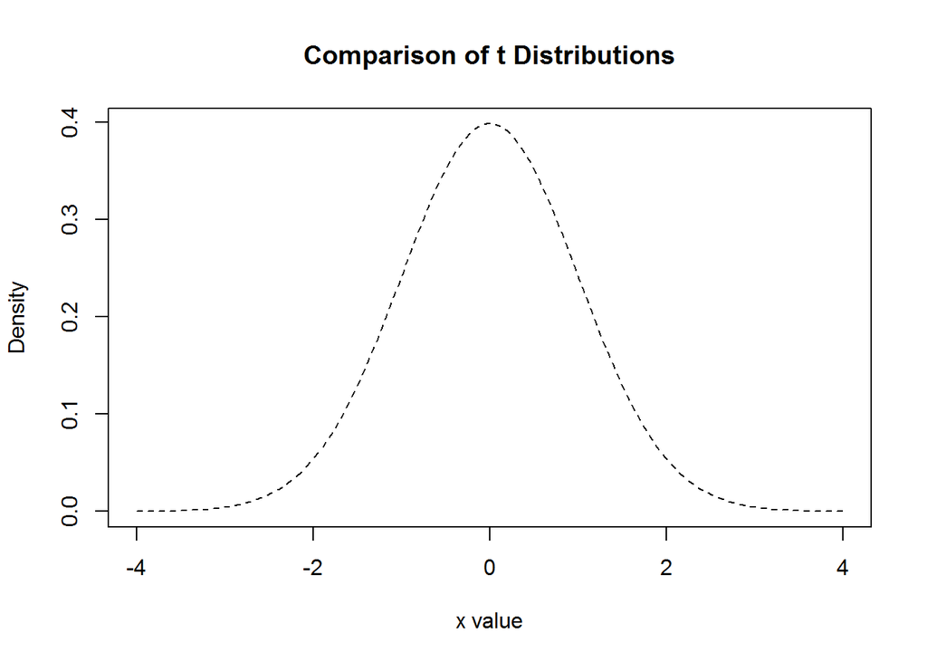

```r
x <- seq(-4, 4, length=100)
hx <- dnorm(x)
plot(x, hx, type="l", lty=2, xlab="x value", ylab="Density", main="Comparison of t Distributions")
```

```r
mean(hx)
```

```
## [1] 0.1237434
```

```r
runif(x)
```

```
##   [1] 0.346997409 0.018262816 0.713741708 0.887510720 0.244454738
##   [6] 0.235485506 0.057532352 0.031300199 0.490928877 0.996311223
##  [11] 0.475155273 0.172477755 0.131678641 0.375156107 0.047044620
##  [16] 0.708109205 0.680663401 0.003548067 0.293221615 0.258364725
##  [21] 0.248527036 0.752861370 0.258619218 0.436968440 0.604380445
##  [26] 0.568817845 0.612143957 0.233348291 0.181030701 0.408162657
##  [31] 0.795288032 0.040809571 0.918816331 0.737810896 0.344916738
##  [36] 0.817004413 0.748677600 0.182593278 0.410420625 0.639921761
##  [41] 0.930260155 0.040055425 0.034114951 0.954127578 0.329130553
##  [46] 0.007415039 0.773208513 0.890375936 0.868021747 0.851441400
##  [51] 0.867591908 0.385043049 0.373329206 0.571278410 0.881413678
##  [56] 0.185022455 0.108731220 0.130280830 0.485476321 0.036339381
##  [61] 0.910207273 0.455076860 0.248462222 0.015724801 0.944230334
##  [66] 0.012766516 0.540698194 0.880754207 0.587314767 0.658615719
##  [71] 0.878404639 0.270470622 0.231872075 0.054725091 0.501886801
##  [76] 0.675127877 0.953988766 0.090941766 0.383819990 0.011979944
##  [81] 0.938302456 0.588480241 0.127903563 0.457223723 0.925427888
##  [86] 0.320502755 0.712313463 0.132566188 0.010989214 0.123322464
##  [91] 0.494928144 0.293769828 0.295895712 0.805214998 0.182302938
##  [96] 0.487374722 0.839513954 0.575408090 0.731540836 0.416692880
```

# Statistical

cor.test() # Perform correlation test

cumsum(); cumprod(); cummin(); cummax() # Cumuluative functions for vectors

density(x) # Compute kernel density estimates

ks.test() # Performs one or two sample Kolmogorov-Smirnov tests

loess(), lowess() # Scatter plot smoothing

mad() # Calculate median absolute deviation

mean(x), weighted.mean(x), median(x), min(x), max(x), quantile(x)

rnorm(), runif() # Generate random data with Gaussian/uniform distribution

splinefun() # Perform spline interpolation

smooth.spline() # Fits a cubic smoothing spline

sd() # Calculate standard deviation

summary(x) # Returns a summary of x: mean, min, max etc.

t.test() # Student’s t-test

var() # Calculate variance

sample() # Random samples & permutations

ecdf() # Empirical Cumulative Distribution Function

qqplot() # quantile-quantile plot

http://www.sr.bham.ac.uk/~ajrs/R/r-function_list.html http://www.statmethods.net/advgraphs/probability.html